# Problem Set 04

2019-10-18

# Learning goals

- Using more data visualization techniques: changing colors and adding trend lines
- Baby’s first data wrangling exercise!

# Honor code

# Setup

Load necessary packages:

```r
library(ggplot2)
library(dplyr)
library(babynames)
```

# Question 1

In this exercise, you’re going to recreate the figure from Midterm I, Question 4, allowing us to visualize the degree to which the names “Casey” and “Riley” were used for babies of both sex male and female.

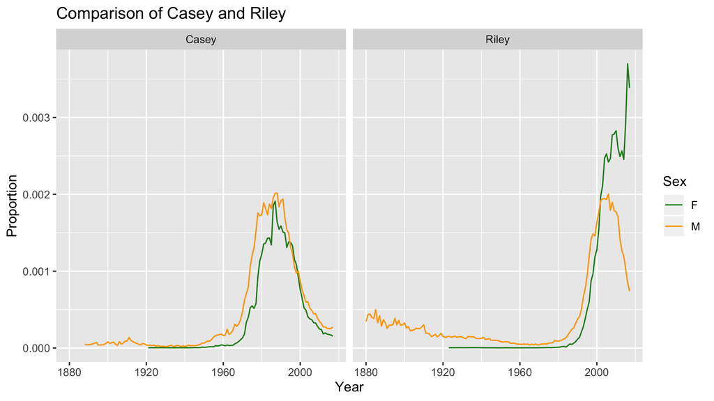

## Part a)

Perform the data wrangling necessary to transform the `babynames` data frame included in the `babynames` package into a new data frame called `babynames_riley_casey` that will allow us to create the visualization.

**Hint**: I recommend you first draw on a piece of paper what the data frame should look like; that way you’ll know what your target looks like and when you’ve hit it.

## Part b)

Recreate the above visualization *exactly*, right down to the manually set colors of the lines (`"forestgreen"` and `"orange"`) and the capitalization of all text.

## Part c)

Once again, recreate the above figure *exactly*, however this time add an appropriately chosen trend lines. For clarity’s sake, do NOT include the standard error bars.

# Bonus

In this exercise, you’re going to once again recreate the figure from Midterm I, Question 4. This time however, you’re going to limit it to years 1960 and later:

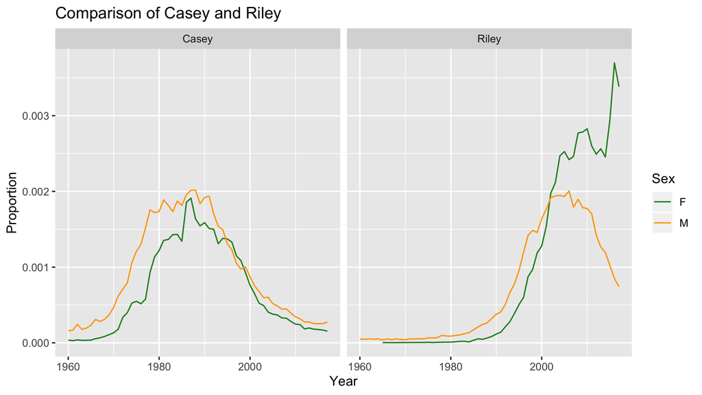

## Part a)

Perform the data wrangling necessary to transform the `babynames` data frame included in the `babynames` package into a new data frame `babynames_riley_casey_1960_later` that only has data for 1960 or later.

**Hint** There are many ways to do this. The following hint may (or may not) prove useful depending which way you choose: [Precedence of Logical Operators](https://chortle.ccsu.edu/Java5/Notes/chap40/ch40_16.html).